# ESM 204 - HW4

Lucas Boyd & Max Settineri

5/16/2022

# Uncertainty and the Social Cost of Carbon

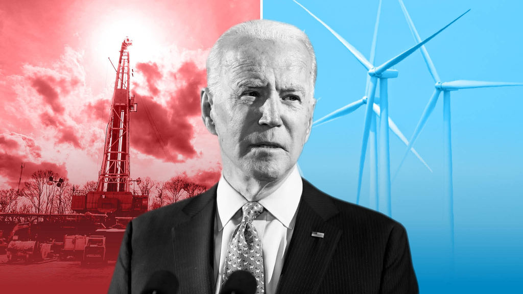

```r
knitr::opts_chunk$set(echo = TRUE, message = FALSE, warning = FALSE)
library(tidyverse)
library(here)
library(broom)
library(patchwork)

options(scipen = 999)

# reading in damages data, creating new column for squared damages
damages <- read_csv(here("damages.csv")) %>%
  mutate(warming_q = warming^2)

# reading in warming data
warming <- read_csv(here("warming.csv"))
```

## 1. Quadratic model

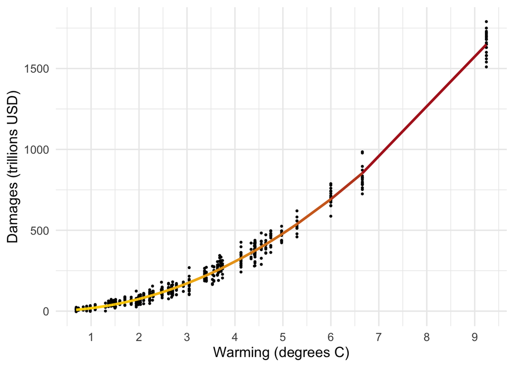

```r
# creating a quadratic model
qm_damages <- lm(damages ~ 0 + warming + warming_q, data = damages)
damages_predict <- augment(qm_damages)

# visualizing the model
ggplot(data = damages, aes(x = warming, y = damages/1e+12)) +
  geom_point(color = "black", size = 0.7) +
  geom_line(data = damages_predict, aes(x = warming, y = .fitted/1e+12, color = .fitted), size = 1.2) +
  scale_color_gradientn(colors = c("gold", "firebrick", "darkred")) +
  theme_minimal(14) +
  labs(x = "Warming (degrees C)", y = "Damages (trillions USD)") +
  scale_x_continuous(n.breaks = 10) +
  theme(legend.position = "none")
```

**Figure 1** shows the damages in trillions of US dollars from climate change that correspond to levels of global warming (degrees C). The line represents a quadratic model fitted to the data.

## 2. The pulse

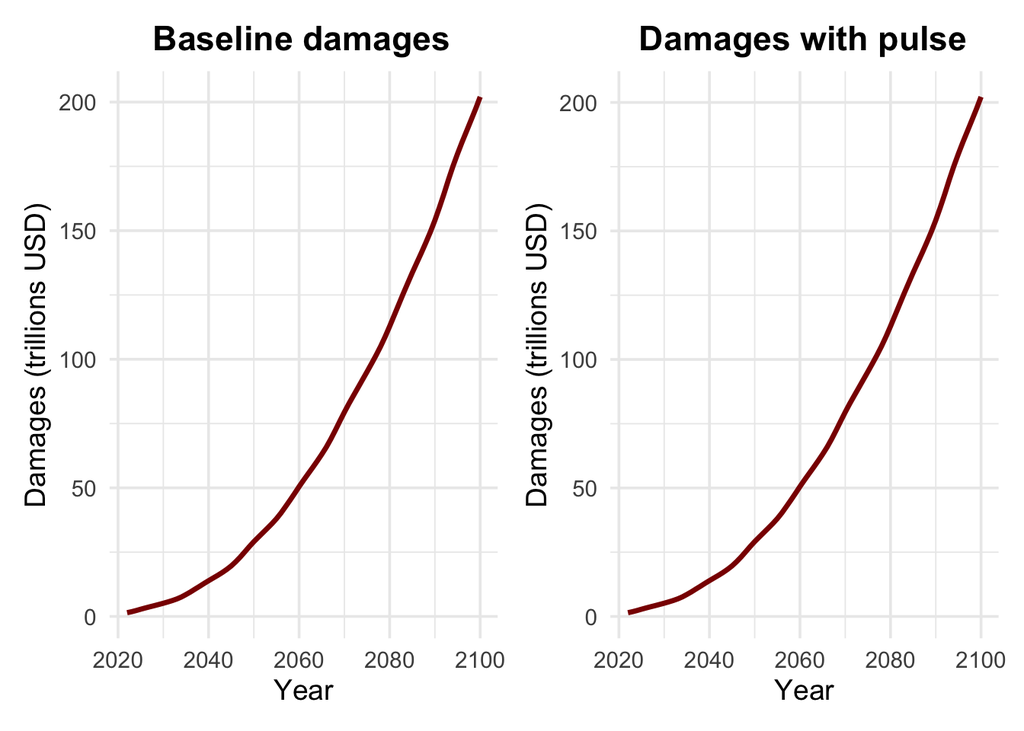

```r
# storing a function for damages from warming based on the quadratic model
damages <- function(warming) {
  damages <- qm_damages$coefficients[1]*warming + qm_damages$coefficients[2]*(warming^2)
  return(damages)
}

# creating a new dataframe with differences and damages per ton based on degrees of warming
pulse <- warming %>%
  mutate(damages_baseline = damages(warming_baseline)) %>%
  mutate(damages_pulse = damages(warming_pulse)) %>%
  mutate(difference = damages_pulse - damages_baseline) %>%
  mutate(damage_per_ton = difference/35e+9)

# plotting
p1 <- ggplot(data = pulse, aes(x = year, y = damages_baseline/1e+12)) +
  geom_line(size = 1.2, color = "darkred") +
  labs(x = "Year", y = "Damages (trillions USD)", title = "Baseline damages") +
  theme_minimal(14) +
  theme(plot.title = element_text(hjust = 0.48, face = "bold"))

p2 <- ggplot(data = pulse, aes(x = year, y = damages_pulse/1e+12)) +
  geom_line(size = 1.2, color = "darkred") +
  labs(x = "Year", y = "Damages (trillions USD)", title = "Damages with pulse") +
  theme_minimal(14) +
  theme(plot.title = element_text(hjust = 0.48, face = "bold"))

p3 <- ggplot(data = pulse, aes(x = year, y = difference/1e+09)) +
  geom_line(size = 1.2, color = "darkred") +
  labs(x = "Year", y = "Damages (billions USD)", title = "Additional damages from pulse") +
  theme_minimal(14) +
  theme(plot.title = element_text(hjust = 0.48, face = "bold"))

p4 <- ggplot(data = pulse, aes(x = year, y = difference/35e+9)) +
  geom_line(size = 1.2, color = "darkred") +
  labs(x = "Year", y = "Damages per ton CO2 (USD)", title = "Per ton of CO2") +
  theme_minimal(14) +
  theme(plot.title = element_text(hjust = 0.48, face = "bold"))

p1 | p2
```

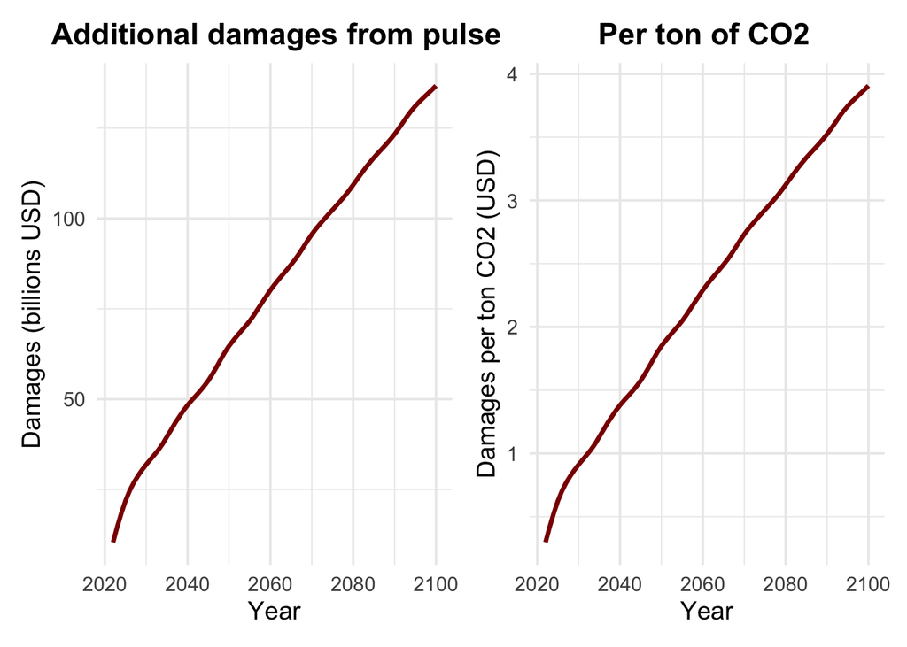

```r
p3 | p4
```

## 3. Social cost of carbon

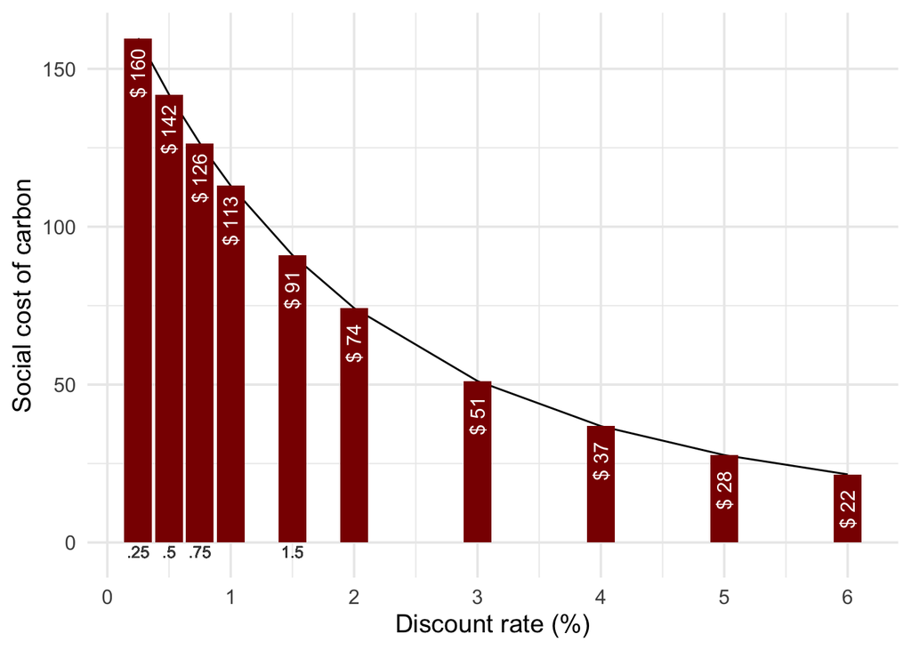

```r
# creating a dataframe with discounted damages based on several discount rates
scc <- pulse %>%
  mutate(years_into_future = year-2022) %>%
  mutate(scc_not_discounted = difference/35e+9) %>%
  mutate(dr0.25 = scc_not_discounted/(1.0025^years_into_future)) %>%
  mutate(dr0.5 = scc_not_discounted/(1.005^years_into_future)) %>%
  mutate(dr0.75 = scc_not_discounted/(1.0075^years_into_future)) %>%
  mutate(dr1 = scc_not_discounted/(1.01^years_into_future)) %>%
  mutate(dr1.5 = scc_not_discounted/(1.015^years_into_future)) %>%
  mutate(dr2 = scc_not_discounted/(1.02^years_into_future)) %>%
  mutate(dr3 = scc_not_discounted/(1.03^years_into_future)) %>%
  mutate(dr4 = scc_not_discounted/(1.04^years_into_future)) %>%
  mutate(dr5 = scc_not_discounted/(1.05^years_into_future)) %>%
  mutate(dr6 = scc_not_discounted/(1.06^years_into_future)) %>%
  mutate(dr2.1 = scc_not_discounted/(1.021^years_into_future))


scc0.025 <- sum(scc$dr0.25)
scc0.5 <- sum(scc$dr0.5)
scc0.75 <- sum(scc$dr0.75)
scc1 <- sum(scc$dr1)
scc1.5 <- sum(scc$dr1.5)
scc2 <- sum(scc$dr2)
scc3 <- sum(scc$dr3)
scc4 <- sum(scc$dr4)
scc5 <- sum(scc$dr5)
scc6 <- sum(scc$dr6)

scc_vector <- c(scc0.025, scc0.5, scc0.75, scc1, scc1.5, scc2, scc3, scc4, scc5, scc6)
dr <- c(0.25, 0.5, 0.75, 1, 1.5, 2, 3, 4, 5, 6)
scc_table <- data.frame(scc_vector, dr)

# plotting SCC vs. discount rate
ggplot(data = scc_table, aes(x = dr, y = scc_vector)) +
    geom_line() +
  geom_col(size = 3, fill = "darkred") +
  labs(x = "Discount rate (%)", y = "Social cost of carbon") +
  theme_minimal(14) +
  scale_x_continuous(n.breaks = 10) +
  # geom_text(aes(x = dr, y = scc_vector, label = dr), nudge_y = 4) +
  geom_text(aes(x = dr, y = scc_vector, label = paste("$", round(scc_vector, 0))), nudge_y = -11, angle = 90, color = "white ") +
  geom_text(aes(x = 0.25, y = -3, label = ".25"), size = 3.2, color = "grey28") +
  geom_text(aes(x = 0.5, y = -3, label = ".5"), size = 3.2, color = "grey28") +
  geom_text(aes(x = 0.75, y = -3, label = ".75"), size = 3.2, color = "grey28") +
  geom_text(aes(x = 1.5, y = -3, label = "1.5"), size = 3.2, color = "grey28")
```

**Figure 3** shows the social cost of carbon at several different plausible discount rates

**Explanation:** As the discount rate increases, we place more value on near-term benefits and damages than future benefits and damages. The social cost of carbon reflects the price we assign to the future damages of one ton of carbon emissions. Thus, as the discount rate increases we will weigh future damages as less important, and the social cost of carbon will be lower.

## 4. The Ramsey Rule

```r
# calculating the discount rate using the ramsey rule from the information given
rr <- (0.001 + 2*0.01)*100
```

### Using the Ramsey Rule, we find our discount rate to be **2.1%**

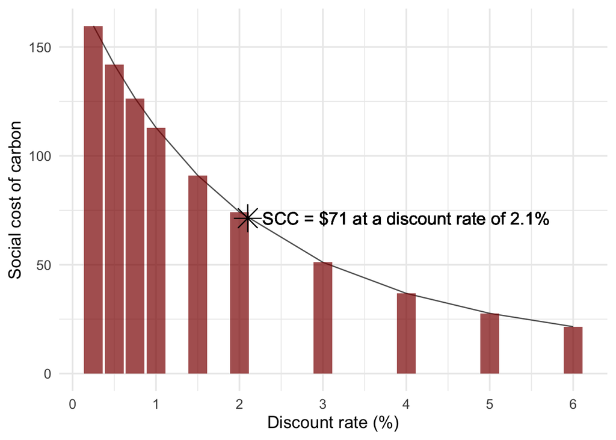

```r
# calculating the social cost of carbon using the ramsey rule
scc2.1 <- sum(scc$dr2.1)


# locating this discount rate on the graph
ggplot(data = scc_table, aes(x = dr, y = scc_vector)) +
    geom_line(alpha = 0.7) +
  geom_col(size = 3, fill = "darkred", alpha = 0.7) +
  labs(x = "Discount rate (%)", y = "Social cost of carbon") +
  theme_minimal(14) +
  scale_x_continuous(n.breaks = 10) +
  geom_point(aes(y = scc2.1, x = rr), size = 7, shape = 8) +
  geom_text(aes(y = scc2.1, x = 4, label = "SCC = $71 at a discount rate of 2.1%"), size = 5, shape = 8)
```

## 5. Climate policies

```r
# creating a dataframe to calculate expected values
policy <- pulse %>%
  mutate(warming_policy_a = 1.5*warming_baseline) %>% # 0.5 chance of this occurring under A
  mutate(warming_policy_b = ifelse(year < 2050, warming_policy_a, 1.29)) %>% # 100% chance of this occurring under B
  mutate(damages_a = damages(warming_policy_a)) %>%
  mutate(damages_b = damages(warming_policy_b)) %>%
  mutate(years_into_future = year-2022) %>%
  mutate(damages_a_discounted = damages_a/(1.02^years_into_future)) %>%
  mutate(damages_b_discounted = damages_b/(1.02^years_into_future)) %>%
  mutate(damages_baseline_discounted = damages_baseline/(1.02^years_into_future))

# expected values
ev_a <- 0.5*sum(policy$damages_baseline_discounted) + 0.5*sum(policy$damages_a_discounted)
ev_b <- sum(policy$damages_b_discounted)
```

### Damages under each policy

Expected present value of damages up to 2100 under **Policy A**: $3023 trillion

Expected present value of damages up to 2100 under **Policy B**: $1064 trillion

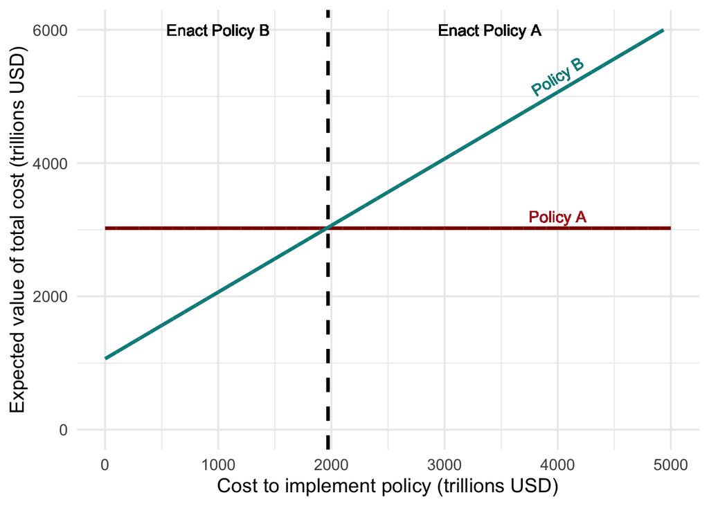

```r
# sequence for cost
cost <- seq(0, 5e15, by = 1e12)

cost_df <- data.frame(cost)

cost_compare <- cost_df %>%
  mutate(cost_b = ev_b + cost) %>%
  mutate(cost_a = ev_a)

# visualizing cost and damages of policy options
ggplot(data = cost_compare) +
  geom_line(aes(x = cost/1e12, y = cost_a/1e12), size = 1.2, color = "darkred") +
  geom_line(aes(x = cost/1e12, y = cost_b/1e12), size = 1.2, color = "cyan4") +
  theme_minimal(14) +
  labs(x = "Cost to implement policy (trillions USD)", y = "Expected value of total cost (trillions USD)") +
  geom_text(aes(x = 4000, y = 3200, label = "Policy A"), color = "firebrick", size = 4) +
  geom_text(aes(x = 4000, y = 5300, label = "Policy B"), color = "cyan4", angle = 32, size = 4) +
  geom_vline(xintercept = 1970, linetype = "dashed", size = 1.2) +
  geom_text(aes(x = 1000, y = 6000, label = "Enact Policy B"), size = 4) +
  geom_text(aes(x = 3400, y = 6000, label = "Enact Policy A"), size = 4) +
  scale_y_continuous(limits = c(0, 6000))
```

**Advice to Congress:** Based on the plot above, Congress should enact Policy B if it costs less than ~$2000 trillion to implement. At any price below that, the total expected value of the cost Policy B (damages + cost to implement) is less than the total expected value of the cost of Policy A (damages). Since society is risk neutral, the expected utility is equal to the expected value. Given that every climate policy ever proposed has been many magnitudes below this number, I’d say it’s probably time for congress to enact some climate policy.

## 6. Risk aversion

If society is risk averse, congress will be more likely to enact Policy B. They will take the more conservative approach.